```python
import matplotlib.pyplot as plt
import matplotlib.cbook as cbk
import pandas as pd
import numpy as np
import seaborn as sns
from sklearn.model_selection import train_test_split
from sklearn.metrics import (confusion_matrix, accuracy_score)
from sklearn.cluster import KMeans
from sklearn import metrics
from sklearn.metrics import mean_squared_error
from math import dist
import statsmodels.api as sm
import statsmodels.formula.api as smf
from statsmodels.stats.diagnostic import het_breuschpagan
from statsmodels.stats.outliers_influence import variance_inflation_factor
from scipy.stats import t, shapiro
```

```python
billets = pd.read_csv("billets.csv", sep = ";")
```

[figure not shown]

# Sommaire

I. Analyse descriptive des données  
II. Nettoyage des données  
III. Régression logistique  
IV. Kmeans et distance euclidienne  
V. Application finale

# I Analyse descriptive des données

Nous disposons de six informations géométriques sur un billet :

- length : la longueur du billet (en mm) ;
- height_left : la hauteur du billet (mesurée sur le côté gauche, en mm) ;
- height_right : la hauteur du billet (mesurée sur le côté droit, en mm) ;
- margin_up : la marge entre le bord supérieur du billet et l'image de celui-ci (en mm) ;
- margin_low : la marge entre le bord inférieur du billet et l'image de celui-ci (en mm) ;
- diagonal : la diagonale du billet (en mm)

```python
billets.describe(include = 'all')
```

|  | is_genuine | diagonal | height_left | height_right | margin_low | margin_up | length |
| --- | --- | --- | --- | --- | --- | --- | --- |
| count | 1500 | 1500.000000 | 1500.000000 | 1500.000000 | 1463.000000 | 1500.000000 | 1500.00000 |
| unique | 2 | NaN | NaN | NaN | NaN | NaN | NaN |
| top | True | NaN | NaN | NaN | NaN | NaN | NaN |
| freq | 1000 | NaN | NaN | NaN | NaN | NaN | NaN |
| mean | NaN | 171.958440 | 104.029533 | 103.920307 | 4.485967 | 3.151473 | 112.67850 |
| std | NaN | 0.305195 | 0.299462 | 0.325627 | 0.663813 | 0.231813 | 0.87273 |
| min | NaN | 171.040000 | 103.140000 | 102.820000 | 2.980000 | 2.270000 | 109.49000 |
| 25% | NaN | 171.750000 | 103.820000 | 103.710000 | 4.015000 | 2.990000 | 112.03000 |
| 50% | NaN | 171.960000 | 104.040000 | 103.920000 | 4.310000 | 3.140000 | 112.96000 |
| 75% | NaN | 172.170000 | 104.230000 | 104.150000 | 4.870000 | 3.310000 | 113.34000 |
| max | NaN | 173.010000 | 104.880000 | 104.950000 | 6.900000 | 3.910000 | 114.44000 |

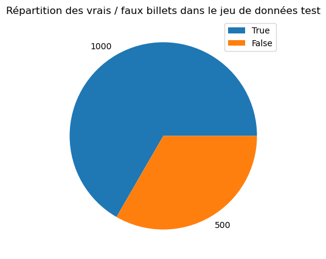

```python
fig = plt.figure(figsize= (10,5))
plt.pie(billets["is_genuine"].value_counts(),  labels = billets["is_genuine"].value_counts())
plt.legend(billets["is_genuine"].unique(), loc = "upper right")
plt.title("Répartition des vrais / faux billets dans le jeu de données test")
plt.show()
```

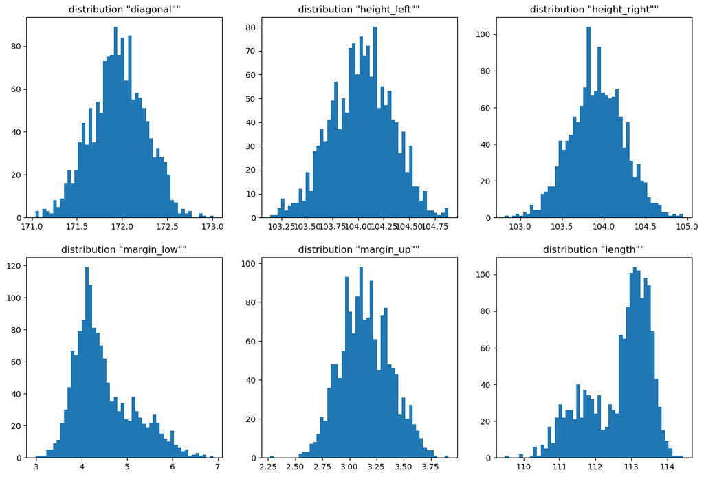

```python
fig = plt.figure(figsize = (15,10))
for i,col in enumerate (np.array(billets.columns[1:])) :
    ax = fig.add_subplot(2,3,i+1)
    ax.hist(billets[col], bins = 50)
    ax.set_title(f'distribution "{col}""')
plt.show()
```

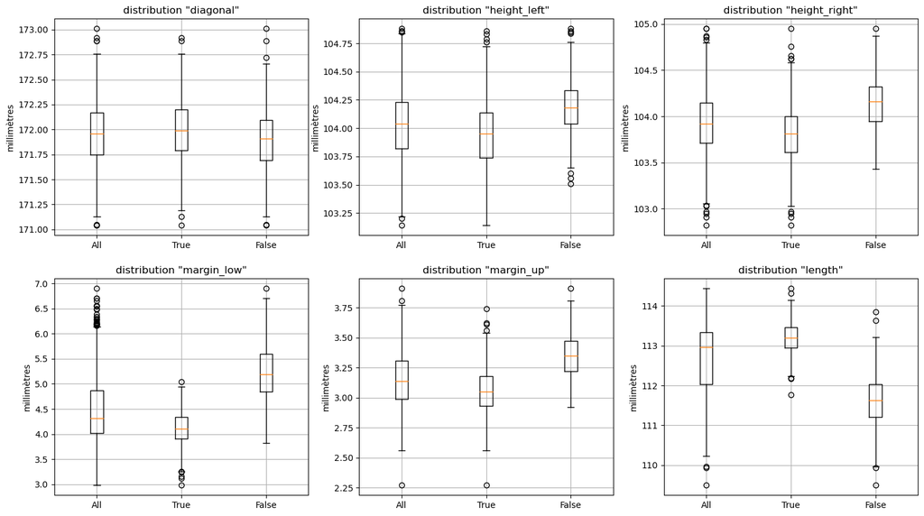

```python
fig = plt.figure(figsize = (18,10))
for i,col in enumerate (np.array(billets.columns[1:])) :
    ax = fig.add_subplot(2,3,i+1)
    ax.boxplot(billets[col].dropna(), positions = [1])
    ax.boxplot(billets[billets["is_genuine"]==True][col].dropna(), positions=[2])
    ax.boxplot(billets[billets["is_genuine"]==False][col].dropna(), positions=[3])
    ax.set_xticklabels(['All', 'True', 'False'])
    ax.grid(True)
    ax.set_title(f'distribution "{col}"')
    ax.set_ylabel('millimètres')
plt.show()
```

On constate qu'il existe des différences géométriques entre le groupe "vrais billets" et le groupe "faux billets". D'après l'allure des boxplot, cette différence est particulièrement marquée sur les variables "length" et"margin_low"

```python
for i,col in enumerate (np.array(billets.columns[1:])) :
    boxplotstats = cbk.boxplot_stats(billets[col].dropna())
    print(f'statistiques {col} :')
    print(boxplotstats)
    index_outliers = billets[billets[col].isin(boxplotstats[0]['fliers'])].index.values
    print(f'outliers : billet authentique ? {col} :')
    print(billets.iloc[index_outliers]["is_genuine"])
```

```
statistiques diagonal :
[{'mean': 171.95844000000002, 'iqr': 0.4199999999999875, 'cilo': 171.9429743652101, 'cihi': 171.97702563478992, 'whishi': 172.76, 'whislo': 171.13, 'fliers': array([171.04, 171.04, 171.05, 172.92, 172.89, 172.89, 173.01]), 'q1': 171.75, 'med': 171.96, 'q3': 172.17}]
outliers : billet authentique ? diagonal :
729      True
828      True
842      True
1022    False
1142    False
1277    False
1388    False
Name: is_genuine, dtype: bool
statistiques height_left :
[{'mean': 104.02953333333332, 'iqr': 0.4100000000000108, 'cilo': 104.02337973746698, 'cihi': 104.05662026253303, 'whishi': 104.84, 'whislo': 103.22, 'fliers': array([103.2 , 103.14, 104.86, 104.88, 104.86, 104.85]), 'q1': 103.82, 'med': 104.04, 'q3': 104.23}]
outliers : billet authentique ? height_left :
0        True
224      True
292      True
1090    False
1150    False
1382    False
Name: is_genuine, dtype: bool
statistiques height_right :
[{'mean': 103.92030666666668, 'iqr': 0.44000000000001194, 'cilo': 103.90216362069627, 'cihi': 103.93783637930373, 'whishi': 104.8, 'whislo': 103.06, 'fliers': array([103.03, 102.97, 102.95, 102.82, 102.91, 103.04, 104.95, 104.87,
       104.86, 104.83, 104.95]), 'q1': 103.71, 'med': 103.92, 'q3': 104.15}]
outliers : billet authentique ? height_right :
0        True
77       True
176      True
193      True
251      True
522      True
761      True
1199    False
1321    False
1331    False
1484    False
Name: is_genuine, dtype: bool
statistiques margin_low :
[{'mean': 4.485967190704033, 'iqr': 0.8550000000000004, 'cilo': 4.2749051327429175, 'cihi': 4.345094867257082, 'whishi': 6.14, 'whislo': 2.98, 'fliers': array([6.2 , 6.7 , 6.33, 6.65, 6.21, 6.23, 6.3 , 6.56, 6.7 , 6.16, 6.34,
       6.48, 6.49, 6.9 , 6.19, 6.16, 6.28, 6.19, 6.38, 6.25, 6.56, 6.19,
```

[output cut: 26 more lines]

```
Name: is_genuine, dtype: bool
statistiques margin_up :
[{'mean': 3.1514733333333336, 'iqr': 0.31999999999999984, 'cilo': 3.127028087779103, 'cihi': 3.1529719122208975, 'whishi': 3.77, 'whislo': 2.56, 'fliers': array([2.27, 3.91, 3.81]), 'q1': 2.99, 'med': 3.14, 'q3': 3.31}]
outliers : billet authentique ? margin_up :
664      True
1029    False
1270    False
Name: is_genuine, dtype: bool
statistiques length :
[{'mean': 112.6785, 'iqr': 1.3100000000000023, 'cilo': 112.9068962343457, 'cihi': 113.0131037656543, 'whishi': 114.44, 'whislo': 110.22, 'fliers': array([109.49, 109.97, 109.93]), 'q1': 112.03, 'med': 112.96, 'q3': 113.34}]
outliers : billet authentique ? length :
1082    False
1355    False
1453    False
Name: is_genuine, dtype: bool
```

Remarque : les outliers sur les variables « length » et « margin low » sont tous catégorisés comme « faux billets »

# II Nettoyage des données

## 1 Recherche des doublons et des valeurs nulles

```python
billets.duplicated().value_counts()
```

```
False    1500
dtype: int64
```

Il n'y a pas de doublons sur nos données

```python
billets.info()
```

```
<class 'pandas.core.frame.DataFrame'>
RangeIndex: 1500 entries, 0 to 1499
Data columns (total 7 columns):
 #   Column        Non-Null Count  Dtype
---  ------        --------------  -----
 0   is_genuine    1500 non-null   bool
 1   diagonal      1500 non-null   float64
 2   height_left   1500 non-null   float64
 3   height_right  1500 non-null   float64
 4   margin_low    1463 non-null   float64
 5   margin_up     1500 non-null   float64
 6   length        1500 non-null   float64
dtypes: bool(1), float64(6)
memory usage: 71.9 KB
```

```python
billets.info()
```

```
<class 'pandas.core.frame.DataFrame'>
RangeIndex: 1500 entries, 0 to 1499
Data columns (total 7 columns):
 #   Column        Non-Null Count  Dtype
---  ------        --------------  -----
 0   is_genuine    1500 non-null   bool
 1   diagonal      1500 non-null   float64
 2   height_left   1500 non-null   float64
 3   height_right  1500 non-null   float64
 4   margin_low    1463 non-null   float64
 5   margin_up     1500 non-null   float64
 6   length        1500 non-null   float64
dtypes: bool(1), float64(6)
memory usage: 71.9 KB
```

```python
billets.isnull().mean()
```

```
is_genuine      0.000000
diagonal        0.000000
height_left     0.000000
height_right    0.000000
margin_low      0.024667
margin_up       0.000000
length          0.000000
dtype: float64
```

On constate qu'il existe des données manquantes sur la variable "margin_low". Une approche possible pour remplacer ces valeurs nulles consiste à utiliser la régression linéaire, simple ou multiple. Dans un premier temps, nous allons rechercher les corrélations linéaires existantes entre "margin_low" et les autres variables dans le but de réaliser une régression linéaire simple.

```
Représentation de la variable margin_low  fonction des autres dimensions
```

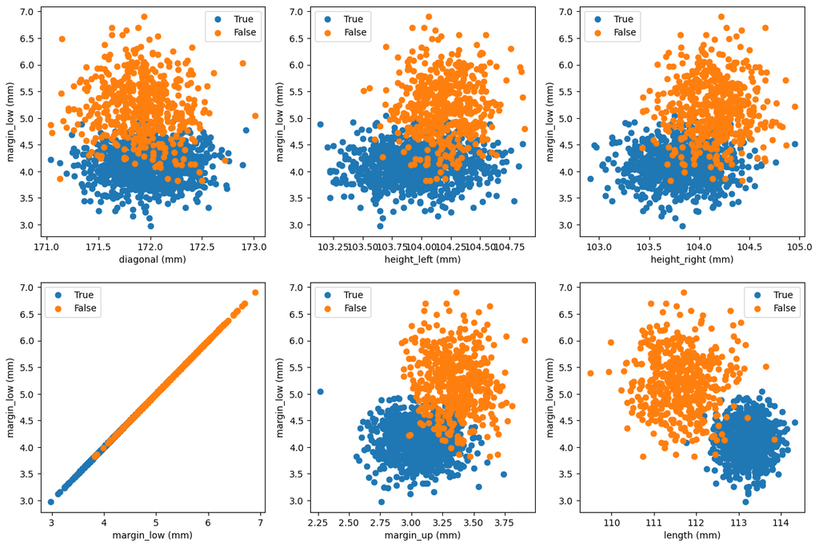

```python
print("Représentation de la variable margin_low  fonction des autres dimensions")
fig = plt.figure(figsize = (15,10))
for i,col in enumerate (np.array(billets.columns[1:])) :
    ax = fig.add_subplot(2,3,i+1)
    ax.scatter(billets[billets["is_genuine"]==True][col], billets[billets["is_genuine"]==True]["margin_low"])
    ax.scatter(billets[billets["is_genuine"]==False][col], billets[billets["is_genuine"]==False]["margin_low"])
    ax.set_xlabel(f'{col} (mm)')
    ax.set_ylabel("margin_low (mm)")
    ax.legend((True, False))

plt.show()
```

Calcul des coefficients de corrélation de Pearson

```python
billets.corr()
```

|  | is_genuine | diagonal | height_left | height_right | margin_low | margin_up | length |
| --- | --- | --- | --- | --- | --- | --- | --- |
| is_genuine | 1.000000 | 0.132756 | -0.379833 | -0.485092 | -0.783032 | -0.606262 | 0.849285 |
| diagonal | 0.132756 | 1.000000 | 0.019472 | -0.024492 | -0.111534 | -0.055649 | 0.097587 |
| height_left | -0.379833 | 0.019472 | 1.000000 | 0.242279 | 0.302643 | 0.246522 | -0.320863 |
| height_right | -0.485092 | -0.024492 | 0.242279 | 1.000000 | 0.391085 | 0.307005 | -0.401751 |
| margin_low | -0.783032 | -0.111534 | 0.302643 | 0.391085 | 1.000000 | 0.431606 | -0.666753 |
| margin_up | -0.606262 | -0.055649 | 0.246522 | 0.307005 | 0.431606 | 1.000000 | -0.520575 |
| length | 0.849285 | 0.097587 | -0.320863 | -0.401751 | -0.666753 | -0.520575 | 1.000000 |

Le calcul des coefficients de Pearson ainsi que l'allure des scatters plot confirme une corrélation linaire plus importante entre les variables margin_low et length. Pour la réalisation de la régression linéaire simple, nous allons donc utilser la variable"length".

## 2 Remplacement des valeurs nullles

### a) Régression linéaire simple

On réalise une regression linéraire simple en utilisant la variable "length", qui est la plus corrélée linéairement avec la variable "margin_low", d'après l'étude des coefficients de corrélation de Pearson

```python
billets[billets["margin_low"].isnull()==False][["margin_low", "length"]]
```

|  | margin_low | length |
| --- | --- | --- |
| 0 | 4.52 | 112.83 |
| 1 | 3.77 | 113.09 |
| 2 | 4.40 | 113.16 |
| 3 | 3.62 | 113.51 |
| 4 | 4.04 | 112.54 |
| ... | ... | ... |
| 1495 | 4.42 | 111.28 |
| 1496 | 5.27 | 110.97 |
| 1497 | 5.51 | 111.95 |
| 1498 | 5.17 | 112.25 |
| 1499 | 4.63 | 112.07 |

1463 rows × 2 columns

```python
#on élimine les lignes où margin low est nulle
reg_simp = smf.ols('margin_low ~ length', data=billets[billets["margin_low"].isnull()==False][["margin_low", "length"]]).fit()
```

```python
print(reg_simp.summary())
```

```
                            OLS Regression Results
==============================================================================
Dep. Variable:             margin_low   R-squared:                       0.445
Model:                            OLS   Adj. R-squared:                  0.444
Method:                 Least Squares   F-statistic:                     1169.
Date:                Fri, 11 Mar 2022   Prob (F-statistic):          8.98e-189
Time:                        11:08:34   Log-Likelihood:                -1045.8
No. Observations:                1463   AIC:                             2096.
Df Residuals:                    1461   BIC:                             2106.
Df Model:                           1
Covariance Type:            nonrobust
==============================================================================
                 coef    std err          t      P>|t|      [0.025      0.975]
------------------------------------------------------------------------------
Intercept     61.5960      1.670     36.881      0.000      58.320      64.872
length        -0.5069      0.015    -34.196      0.000      -0.536      -0.478
==============================================================================
Omnibus:                       95.156   Durbin-Watson:                   1.866
Prob(Omnibus):                  0.000   Jarque-Bera (JB):              133.014
Skew:                           0.552   Prob(JB):                     1.31e-29
Kurtosis:                       3.980   Cond. No.                     1.45e+04
==============================================================================

Notes:
[1] Standard Errors assume that the covariance matrix of the errors is correctly specified.
[2] The condition number is large, 1.45e+04. This might indicate that there are
strong multicollinearity or other numerical problems.
```

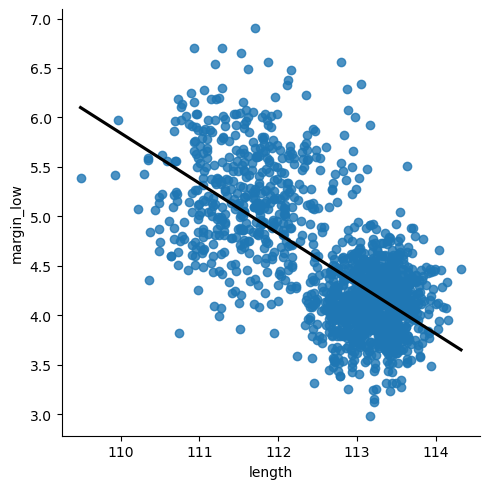

```python
ax = sns.lmplot(x="length", y="margin_low", data=billets, ci=None, line_kws={'color':'black'})
ax.set(xlabel='length', ylabel='margin_low')
ax.set_titles("Droite de régression")
plt.show()
```

### b) Evaluation du modèle de regression linéaire simple

#### Valeurs et significativité des paramètres

Le paramètre β1(intercept) est environ égal à 62.

Nous obtenons les résultats du test statistique réalisé : la statistique de test de Student, et la p-valeur. Le test effectué sur le paramètre est un test de significativité : le paramètre vaut 0 versus le paramètre est différent de 0.

Les p-values sont inférieures à 5 %. À un niveau de test de 5 %, on rejette donc l'hypothèse selon laquelle le paramètre β2 est égal à 0 : les paramètres sont donc significativement différents de 0.

On conclut que la variable "length" est significative.

#### Coefficient de détermination

$R^{2}$ représente le carré de la corrélation de Pearson entre valeurs ajustées et vraies valeurs.

Si R2=1 , on a alors SCE=SCT : toute la variation est expliquée par le modèle.

Si R2=0 , on a alors SCR=SCT : aucune variation n'est expliquée par le modèle.

**Ici,le coefficient $R^{2}$ est de l'ordre de 0.44**

```python
#on recupère les valeurs estimées par le modèle d'entraînement pour les comparer aux vrais valeurs
margin_low_adjust = reg_simp.predict()
```

#### RMSE

```python
print("RMSE : {:.2f}".format((mean_squared_error(billets["margin_low"].dropna(), margin_low_adjust, squared= False))))
```

```
RMSE : 0.49
```

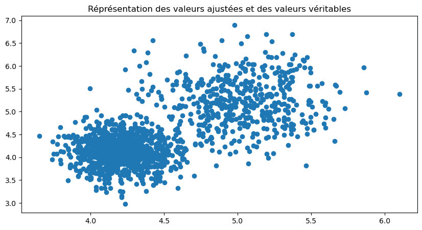

```python
fig = plt.figure(figsize = (10,5))
plt.scatter(margin_low_adjust, billets["margin_low"].dropna())
plt.title("Réprésentation des valeurs ajustées et des valeurs véritables")
plt.show()
```

#### Histogramme des résidus

```python
residu_s = reg_simp.resid
```

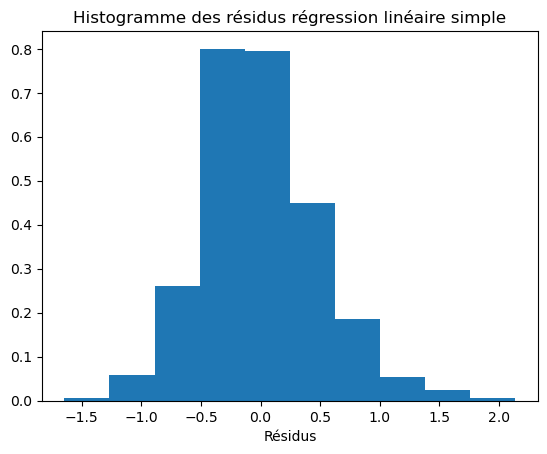

```python
plt.hist(residu_s, density=True)
plt.xlabel('Résidus')
plt.title('Histogramme des résidus régression linéaire simple')
plt.show()
```

L'histogramme est à peu près centré et symétrique

```python
a_predire = billets[billets["margin_low"].isnull()]["length"]
```

```python
margin_low_pred = reg_simp.predict(a_predire)
margin_low_pred
```

```
72      4.427556
99      4.280567
151     4.356596
197     4.184264
241     4.645504
251     4.209607
284     4.174127
334     4.138647
410     4.346458
413     4.346458
445     4.336321
481     3.819327
505     3.991658
611     4.402213
654     4.427556
```

[output cut: 23 more lines]

### c) Régression linéaire multiple

```python
data_reg_multi = billets.iloc[:,1:]
data_reg_multi.head()
```

|  | diagonal | height_left | height_right | margin_low | margin_up | length |
| --- | --- | --- | --- | --- | --- | --- |
| 0 | 171.81 | 104.86 | 104.95 | 4.52 | 2.89 | 112.83 |
| 1 | 171.46 | 103.36 | 103.66 | 3.77 | 2.99 | 113.09 |
| 2 | 172.69 | 104.48 | 103.50 | 4.40 | 2.94 | 113.16 |
| 3 | 171.36 | 103.91 | 103.94 | 3.62 | 3.01 | 113.51 |
| 4 | 171.73 | 104.28 | 103.46 | 4.04 | 3.48 | 112.54 |

```python
data_reg_multi = data_reg_multi[data_reg_multi["margin_low"].isnull()==False]
```

```python
#on retire les données pour lesquelles margin_low est nulle
reg_multi = smf.ols('margin_low~diagonal+height_left++height_right+margin_up+length', data=data_reg_multi).fit()
print(reg_multi.summary())
```

```
                            OLS Regression Results
==============================================================================
Dep. Variable:             margin_low   R-squared:                       0.477
Model:                            OLS   Adj. R-squared:                  0.476
Method:                 Least Squares   F-statistic:                     266.1
Date:                Fri, 11 Mar 2022   Prob (F-statistic):          2.60e-202
Time:                        11:08:35   Log-Likelihood:                -1001.3
No. Observations:                1463   AIC:                             2015.
Df Residuals:                    1457   BIC:                             2046.
Df Model:                           5
Covariance Type:            nonrobust
================================================================================
                   coef    std err          t      P>|t|      [0.025      0.975]
--------------------------------------------------------------------------------
Intercept       22.9948      9.656      2.382      0.017       4.055      41.935
diagonal        -0.1111      0.041     -2.680      0.007      -0.192      -0.030
height_left      0.1841      0.045      4.113      0.000       0.096       0.272
height_right     0.2571      0.043      5.978      0.000       0.173       0.342
margin_up        0.2562      0.064      3.980      0.000       0.130       0.382
length          -0.4091      0.018    -22.627      0.000      -0.445      -0.374
==============================================================================
Omnibus:                       73.627   Durbin-Watson:                   1.893
Prob(Omnibus):                  0.000   Jarque-Bera (JB):               95.862
Skew:                           0.482   Prob(JB):                     1.53e-21
Kurtosis:                       3.801   Cond. No.                     1.94e+05
==============================================================================

Notes:
[1] Standard Errors assume that the covariance matrix of the errors is correctly specified.
[2] The condition number is large, 1.94e+05. This might indicate that there are
strong multicollinearity or other numerical problems.
```

### d) Evaluation du modèle de regression linéaire multiple

#### Valeurs et significativité des paramètres

On remarque que tous les paramètres sont significatifs, d'après les P-values obtenues suite aux tests de Student.

#### Coefficient de détermination

$R^{2}$ vaut environ 0.48, ce qui est supérieur au résultat obtenu par régression linéaire simple.

#### RMSE

```python
#on recupère les valeurs estimées par le modèle d'entraînement pour les comparer aux vrais valeurs
margin_low_adjust_reg_multi = reg_multi.predict()
```

```python
print("RMSE : {:.2f}".format((mean_squared_error(billets["margin_low"].dropna(), margin_low_adjust_reg_multi, squared= False))))
```

```
RMSE : 0.48
```

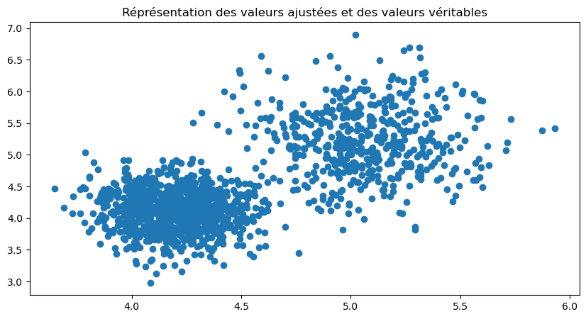

```python
fig = plt.figure(figsize = (10,5))
plt.scatter(margin_low_adjust_reg_multi, billets["margin_low"].dropna())
plt.title("Réprésentation des valeurs ajustées et des valeurs véritables")
plt.show()
```

#### Comparaison des valeurs obtenues par regression linéaire multiple à une approche naïve

```python
dumb_variable = np.full(1463, billets["margin_low"].dropna().mean())
```

```python
print("RMSE : {:.2f}".format((mean_squared_error(billets["margin_low"].dropna(), dumb_variable, squared= False))))
```

```
RMSE : 0.66
```

La regression linéaire multiple obtient un meilleur score RMSE que l'approche naïve (remplacement des valeurs par la moyenne)

#### Etude de la colinéarité des variables (VIF)

```python
variables = reg_multi.model.exog
```

```python
[variance_inflation_factor(variables, i) for i in np.arange(1,variables.shape[1])]
```

```
[1.0136128990686313,
 1.13826057360825,
 1.2301145155560365,
 1.404403778184361,
 1.5769501453665822]
```

Ici, tous les coefficients sont proches de 1, il n'y a donc a priori pas de problème de colinéarité.

#### Histogramme des résidus

```python
residu_s_multi = reg_multi.resid
```

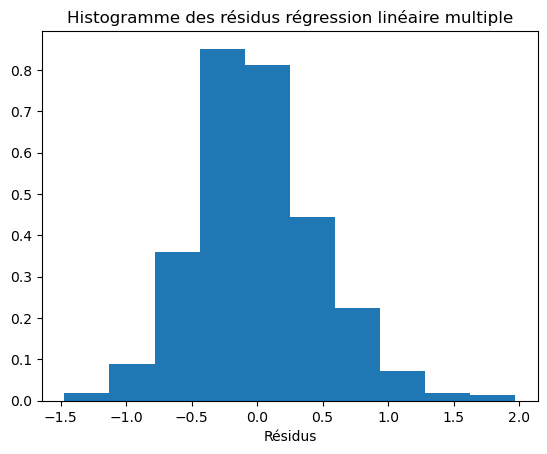

```python
plt.hist(residu_s_multi, density=True)
plt.xlabel('Résidus')
plt.title('Histogramme des résidus régression linéaire multiple')
plt.show()
```

L'histogramme est à peu près centré et symétrique

#### Etude de l’homoscédasticité des résidus

L’homoscédasticité correspond à la constance de la variance

```python
_, pval, __, f_pval = het_breuschpagan(reg_multi.resid, variables)
print('p value test Breusch Pagan:', pval)
```

```
p value test Breusch Pagan: 7.759535216219784e-16
```

La p-valeur ici est inférieure à 5%, on rejette l'hypothèse 𝐻0 selon laquelle les variances sont constantes.

#### Etude de la normalité des résidus

Si le modèle est idéalement bon, alors les écarts constatés entre les valeurs prédites et les valeurs observées sont entièrement dus à des erreurs de mesure. De ce fait, les résidus doivent posséder les propriétés classiques d’une distribution normale

```python
shapiro(reg_multi.resid)
```

```
ShapiroResult(statistic=0.9857879281044006, pvalue=8.536943374437556e-11)
```

Ici, l'hypothèse de normalité est remise en cause (p-value < 0.05)

Au vu des résultats $R^{2}$, des résultats sur l'étude de l'homoscédasticité et du test de la normalité des résidus, on peut se poser la question de la pertinence du remplacement des valeurs par une régression linéaire.

Une autre approche pourrait être de supprimer les lignes comportant des valeurs manquantes.

**Compte tenu de la petite taille de l'échantillon, nous allons tout de même conserver l'ensemble des valeurs en remplaçant les valeurs manquantes de la variable "margin_low" grâce à la regression linéaire multiple.**

### e) Prédiction des valeurs manquantes

```python
a_predire_reg_multi = billets[billets["margin_low"].isnull()][["diagonal","height_left","height_right","margin_up","length"]]
```

```python
margin_low_pred_reg_multi = reg_multi.predict(a_predire_reg_multi)
margin_low_pred_reg_multi
```

```
72      4.318525
99      4.393668
151     4.410457
197     4.319014
241     4.650617
251     3.803308
284     4.179736
334     4.127442
410     4.135034
413     4.160539
445     4.177420
481     3.768554
505     4.058764
611     4.298047
654     4.160607
```

[output cut: 23 more lines]

On remplace les valeurs nulles par les valeurs prédites grâce à la régression linéaire multiple.

```python
billets.loc[billets["margin_low"].isnull(), 'margin_low'] = margin_low_pred_reg_multi
```

# III Régression logistique

## 1 Définition, entraînement et test du modèle

```python
# étiquettes
y = billets['is_genuine']
```

```python
# varaibles explicatives quantitatives
X = billets.iloc[:, 1:]
```

L'algorithme de régression logistique permet de classifier une variable binaire prenant ses valeurs dans {0,1}. Ici, on remplace False par 1 (positif) et True par 0 (négatif)

```python
y = y.replace(to_replace=[False, True], value = [1, 0])
```

```python
#création du jeu d'entraînement et du jeu de test
X_train, X_test, y_train, y_test = train_test_split(X, y, test_size=0.20, stratify=y, random_state=10)
```

```python
# les jeux d'entraînement et de test sont stratifiés : la proportion de points positifs / négatifs est respectée
y_train.value_counts()
```

```
0    800
1    400
Name: is_genuine, dtype: int64
```

```python
y_test.value_counts()
```

```
0    200
1    100
Name: is_genuine, dtype: int64
```

```python
#concaténation du jeu de données d'entraînement
data_train =  pd.concat([y_train, X_train], axis=1)
```

```python
reg_log = smf.glm('is_genuine~diagonal+height_left+height_right+margin_low+margin_up+length',
                   data=data_train, family=sm.families.Binomial()).fit()
print(reg_log.summary())
```

```
                 Generalized Linear Model Regression Results
==============================================================================
Dep. Variable:             is_genuine   No. Observations:                 1200
Model:                            GLM   Df Residuals:                     1193
Model Family:                Binomial   Df Model:                            6
Link Function:                  logit   Scale:                          1.0000
Method:                          IRLS   Log-Likelihood:                -26.506
Date:                Fri, 11 Mar 2022   Deviance:                       53.012
Time:                        11:08:35   Pearson chi2:                     157.
No. Iterations:                    11
Covariance Type:            nonrobust
================================================================================
                   coef    std err          z      P>|z|      [0.025      0.975]
--------------------------------------------------------------------------------
Intercept      622.8439    336.313      1.852      0.064     -36.318    1282.006
diagonal        -1.0748      1.448     -0.742      0.458      -3.913       1.764
height_left      1.9304      1.416      1.363      0.173      -0.845       4.706
height_right     0.9399      1.272      0.739      0.460      -1.553       3.433
margin_low       6.5430      1.212      5.396      0.000       4.167       8.919
margin_up       10.9626      2.716      4.037      0.000       5.640      16.285
length          -7.1251      1.244     -5.727      0.000      -9.564      -4.687
================================================================================
```

On retire la variable height right, qui présente la p_value la plus élevée

```python
reg_log = smf.glm('is_genuine~diagonal+height_left+margin_low+margin_up+length',
                   data=data_train, family=sm.families.Binomial()).fit()
print(reg_log.summary())
```

```
                 Generalized Linear Model Regression Results
==============================================================================
Dep. Variable:             is_genuine   No. Observations:                 1200
Model:                            GLM   Df Residuals:                     1194
Model Family:                Binomial   Df Model:                            5
Link Function:                  logit   Scale:                          1.0000
Method:                          IRLS   Log-Likelihood:                -26.790
Date:                Fri, 11 Mar 2022   Deviance:                       53.580
Time:                        11:08:35   Pearson chi2:                     177.
No. Iterations:                    11
Covariance Type:            nonrobust
===============================================================================
                  coef    std err          z      P>|z|      [0.025      0.975]
-------------------------------------------------------------------------------
Intercept     734.8494    297.423      2.471      0.013     151.911    1317.788
diagonal       -1.2862      1.374     -0.936      0.349      -3.978       1.406
height_left     2.2962      1.333      1.723      0.085      -0.316       4.908
margin_low      6.6406      1.199      5.537      0.000       4.290       8.991
margin_up      11.0916      2.670      4.154      0.000       5.858      16.325
length         -7.2750      1.231     -5.910      0.000      -9.687      -4.862
===============================================================================
```

on retire la variable diagonal

```python
reg_log = smf.glm('is_genuine~height_left+margin_low+margin_up+length',
                   data=data_train, family=sm.families.Binomial()).fit()
print(reg_log.summary())
```

```
                 Generalized Linear Model Regression Results
==============================================================================
Dep. Variable:             is_genuine   No. Observations:                 1200
Model:                            GLM   Df Residuals:                     1195
Model Family:                Binomial   Df Model:                            4
Link Function:                  logit   Scale:                          1.0000
Method:                          IRLS   Log-Likelihood:                -27.213
Date:                Fri, 11 Mar 2022   Deviance:                       54.427
Time:                        11:08:35   Pearson chi2:                     168.
No. Iterations:                    11
Covariance Type:            nonrobust
===============================================================================
                  coef    std err          z      P>|z|      [0.025      0.975]
-------------------------------------------------------------------------------
Intercept     522.5688    179.984      2.903      0.004     169.806     875.332
height_left     2.1785      1.308      1.665      0.096      -0.385       4.743
margin_low      6.8636      1.198      5.731      0.000       4.516       9.211
margin_up      11.2342      2.685      4.185      0.000       5.973      16.496
length         -7.2578      1.223     -5.934      0.000      -9.655      -4.860
===============================================================================
```

on retire la variable height_left, qui présente une p value supérieure à 0,05

```python
reg_log = smf.glm('is_genuine~margin_low+margin_up+length',
                   data=data_train, family=sm.families.Binomial()).fit()
print(reg_log.summary())
```

```
                 Generalized Linear Model Regression Results
==============================================================================
Dep. Variable:             is_genuine   No. Observations:                 1200
Model:                            GLM   Df Residuals:                     1196
Model Family:                Binomial   Df Model:                            3
Link Function:                  logit   Scale:                          1.0000
Method:                          IRLS   Log-Likelihood:                -28.690
Date:                Fri, 11 Mar 2022   Deviance:                       57.380
Time:                        11:08:36   Pearson chi2:                     173.
No. Iterations:                    11
Covariance Type:            nonrobust
==============================================================================
                 coef    std err          z      P>|z|      [0.025      0.975]
------------------------------------------------------------------------------
Intercept    766.9317    127.705      6.006      0.000     516.635    1017.229
margin_low     7.2821      1.212      6.009      0.000       4.907       9.657
margin_up     11.5866      2.650      4.373      0.000       6.393      16.780
length        -7.4415      1.199     -6.204      0.000      -9.792      -5.091
==============================================================================
```

Tous les paramètres sont maintenant significatifs.

```python
#calcul de la probabilité qu'un point soit positif sur le jeu de test
y_pred = reg_log.predict(X_test)
```

```python
# on fixe un seuil de 0,5 pour déterminer si la valeur prédite est positive (> 0,5) ou négative (<0,5)
prediction = list(map(round, y_pred))
```

```python
# confusion matrix
cm_logistic_reg = confusion_matrix(y_test, prediction)
print ("Confusion Matrix (tn, fp, fn, tp) : \n", cm_logistic_reg)
```

```
Confusion Matrix (tn, fp, fn, tp) :
 [[199   1]
 [  2  98]]
```

```python
# accuracy score of the model = proportion de points correctement prédits
print('Test accuracy = ', accuracy_score(y_test, prediction))
```

```
Test accuracy =  0.99
```

```python
#sensibilité = taux de vrais positifs, c’est à dire la proportion de positifs que l’on a correctement identifiés (TP/TP+FN)
#C’est la capacité de notre modèle à détecter tous les faux billets
print(f'Sensibilité : {cm_logistic_reg[1][1]/(cm_logistic_reg[1][1]+cm_logistic_reg[1][0])}')
```

```
Sensibilité : 0.98
```

```python
#spécificité = taux de vrais négatifs, c'est à dire la capacité à détecter tous les vrais billets (TN/TN+FP)
cm_logistic_reg
print(f'Spécificité : {cm_logistic_reg[0][0]/(cm_logistic_reg[0][0]+cm_logistic_reg[0][1])}')
```

```
Spécificité : 0.995
```

## 2 Algorithme regression logistique

```python
def pred_regression_log (csv) :
    dataframe = pd.read_csv(csv)
    dataframe = dataframe.dropna()
    dataframe = dataframe.loc[:,["id","margin_low","margin_up","length"]]
    prob_faux_billet = reg_log.predict(dataframe)
    faux_billet = list(map(round,prob_faux_billet))
    dataframe["prob_faux_billet"] = prob_faux_billet
    dataframe["faux_billet?"] = faux_billet
    dataframe["faux_billet?"] =  dataframe["faux_billet?"].replace(to_replace=[1, 0], value = ["Oui", "Non"])
    return dataframe
```

```python
pred_regression_log("billets_production.csv")
```

|  | id | margin_low | margin_up | length | prob_faux_billet | faux_billet? |
| --- | --- | --- | --- | --- | --- | --- |
| 0 | A_1 | 5.21 | 3.30 | 111.42 | 0.999999 | Oui |
| 1 | A_2 | 6.00 | 3.31 | 112.09 | 1.000000 | Oui |
| 2 | A_3 | 4.99 | 3.39 | 111.57 | 0.999995 | Oui |
| 3 | A_4 | 4.44 | 3.03 | 113.20 | 0.000333 | Non |
| 4 | A_5 | 3.77 | 3.16 | 113.33 | 0.000004 | Non |

# IV KMEANS

## 1 Utilisation des centroïdes issus du kmeans et calcul de la distance euclidienne entre les points et les centroïdes

```python
#définition des clusters par la méthode Kmeans

#nombre de clusters souhaités
n_clust = 2

# clustering par K-means, ici pour récupérer les coordonnées des centroides calculés,
#pour initialisation du kmeans avec init dans un second temps
km_get_centroïdes = KMeans(n_clusters=n_clust, random_state=0)
km_get_centroïdes.fit(X_train)

# récupération des coordonnées des centroïdes pour utilisation dans init
centroids_after_kmeans_get_centroides = km_get_centroïdes.cluster_centers_
```

```python
centroids_after_kmeans_get_centroides
```

```
array([[171.88411917, 104.19069948, 104.12992228,   5.24720037,
          3.34313472, 111.59569948],
       [171.9869656 , 103.95583538, 103.81562654,   4.11834288,
          3.0591769 , 113.19662162]])
```

```python
#création d'un np array avec les coordonnées des centroïdes
centroids_after_kmeans_get_centroides = np.array([[171.88411917, 104.19069948, 104.12992228,   5.24720037,
          3.34313472, 111.59569948],
       [171.9869656 , 103.95583538, 103.81562654,   4.11834288,
          3.0591769 , 113.19662162]])
```

```python
# clustering par K-means avec initialisation des centroïdes aux coordonnées précedemment calculées
km = KMeans(n_clusters=n_clust, init = centroids_after_kmeans_get_centroides, max_iter= 500)
km.fit(X_train)

# récupération des clusters attribués à chaque individu et des coordonnées des centroïdes
clusters_km = km.labels_
centroids_after_kmeans = km.cluster_centers_
```

```python
clusters_km
```

```
array([0, 0, 1, ..., 1, 0, 1])
```

```python
y_train
```

```
1217    1
1207    1
793     0
570     0
739     0
       ..
1247    1
76      0
621     0
1239    1
376     0
Name: is_genuine, Length: 1200, dtype: int64
```

```python
# il semblerait que le numéro de cluster attribué à False, "1", est 0, le numéro de cluster attribué à True, 0, est 1
#vérification avec un crosstab
```

```python
data_train_clusters = pd.DataFrame(y_train)
data_train_clusters["clusters_km"] = clusters_km
```

```python
data_train_clusters
```

|  | is_genuine | clusters_km |
| --- | --- | --- |
| 1217 | 1 | 0 |
| 1207 | 1 | 0 |
| 793 | 0 | 1 |
| 570 | 0 | 1 |
| 739 | 0 | 1 |
| ... | ... | ... |
| 1247 | 1 | 0 |
| 76 | 0 | 1 |
| 621 | 0 | 1 |
| 1239 | 1 | 0 |
| 376 | 0 | 1 |

1200 rows × 2 columns

```python
pd.crosstab(data_train_clusters["is_genuine"], data_train_clusters["clusters_km"], margins=True)
```

| clusters_km is_genuine | 0 | 1 | All |
| --- | --- | --- | --- |
| 0 | 2 | 798 | 800 |
| 1 | 384 | 16 | 400 |
| All | 386 | 814 | 1200 |

```python
# on a 4% des faux billets classés par le kmeans dans le cluster "vrais billets" => false negative
# on a 0.3% des vrais billets classés par le kmeans dans le cluster "faux billets" => false positive
```

```python
#on inverse l'ordre des centroïdes pour faire correspondre l'indice 0 à vrai billet et l'indice 1 à faux billet
centroids_after_kmeans_get_centroides = centroids_after_kmeans_get_centroides[[1,0]]
```

```python
centroids_after_kmeans_get_centroides
```

```
array([[171.9869656 , 103.95583538, 103.81562654,   4.11834288,
          3.0591769 , 113.19662162],
       [171.88411917, 104.19069948, 104.12992228,   5.24720037,
          3.34313472, 111.59569948]])
```

```python
# on peut utiliser la fonction dist de la librairie math pour obtenir la distance euclidienne entre un point et les clusters
```

```python
def predict_kmeans(data):
    centroids, data = np.array(centroids_after_kmeans_get_centroides), np.array(data)
    distances = []
    for unit in data:
        for center in centroids:
            distances.append(dist(unit, center))
    distances = np.reshape(distances, [len(data),n_clust])
    closest_centroid = [np.argmin(dist) for dist in distances]
    return(closest_centroid)
```

```python
#classification des points du jeu de test par l'algotithme Kmeans
predictions_knn = predict_kmeans(X_test)
```

```python
cm_knn = confusion_matrix(y_test, predictions_knn)
print ("Confusion Matrix (tn, fp, fn, tp) : \n", cm_knn)
```

```
Confusion Matrix (tn, fp, fn, tp) :
 [[199   1]
 [  3  97]]
```

```python
print('Test accuracy = ', accuracy_score(y_test, predictions_knn))
```

```
Test accuracy =  0.9866666666666667
```

```python
print(f'Sensibilité : {cm_knn[1][1]/(cm_knn[1][1]+cm_knn[1][0])}')
```

```
Sensibilité : 0.97
```

```python
cm_logistic_reg
print(f'Spécificité : {cm_knn[0][0]/(cm_knn[0][0]+cm_knn[0][1])}')
```

```
Spécificité : 0.995
```

==> Les résultats concerant l'accuracy et la sensibilité sont légèrement supérieurs avec la régression logistique.

## 2 Algorithme Kmeans

```python
def pred_kmeans(csv) :
    dataframe = pd.read_csv(csv)
    dataframe = dataframe.dropna()
    data = dataframe.loc[:,["diagonal","height_left","height_right","margin_low","margin_up","length"]]
    faux_billet = predict_kmeans(data)
    dataframe["faux_billet?"] = faux_billet
    dataframe["faux_billet?"] =  dataframe["faux_billet?"].replace(to_replace=[1, 0], value = ["Oui", "Non"])
    first_column = dataframe.pop("id")
    dataframe.insert(0, 'id', first_column)
    return dataframe
```

```python
pred_kmeans("billets_production.csv")
```

|  | id | diagonal | height_left | height_right | margin_low | margin_up | length | faux_billet? |
| --- | --- | --- | --- | --- | --- | --- | --- | --- |
| 0 | A_1 | 171.76 | 104.01 | 103.54 | 5.21 | 3.30 | 111.42 | Oui |
| 1 | A_2 | 171.87 | 104.17 | 104.13 | 6.00 | 3.31 | 112.09 | Oui |
| 2 | A_3 | 172.00 | 104.58 | 104.29 | 4.99 | 3.39 | 111.57 | Oui |
| 3 | A_4 | 172.49 | 104.55 | 104.34 | 4.44 | 3.03 | 113.20 | Non |
| 4 | A_5 | 171.65 | 103.63 | 103.56 | 3.77 | 3.16 | 113.33 | Non |

# V Application finale

Les résultats concerant l'accuracy et la sensibilité étant légèrement supérieurs avec la régression logistique, c'est l'algorithme retenu pour l'application finale.

[output not shown]

Retour au sommaire